# Assignment 2 - Classification and resampling methods

by Jana Jaber, Hadi Bazzi, and Gaelle Loutfi

(November 18, 2023)

# Car Acceptability Data Set

For this assignment, we will be using a dataset named “DataAssign2.csv”. The dataset comprises several features, each with a set of categorical values, that are hypothesized to influence the overall acceptability of a car.

- We will begin by changing the predictor names to have a more meaningful variables.

```r
# Load the necessary library
library(readr)

# Load the dataset
data <- read_csv("DataAssign2.csv")

# Rename the columns
colnames(data) <- c("Car_Price", "Maintenance_Price", "Nb_of_Doors",
                    "Car_Capacity", "Luggage_Size", "Car_Safety",
                    "Car_Acceptability")

# Overwrite the dataset with the new column names
write_csv(data, "DataAssign2.csv")
```

- What is the `dimension` of our dataset?

```r
dim(data)
```

```
## [1] 260   7
```

- What are the `variables` in our dataset?

```r
names(data)
```

```
## [1] "Car_Price"         "Maintenance_Price" "Nb_of_Doors"
## [4] "Car_Capacity"      "Luggage_Size"      "Car_Safety"
## [7] "Car_Acceptability"
```

- Importing Libraries

```r
library(tidyverse)
library(ggplot2)
library(gt)
library(caret)
library(MASS) # for LDA and QDA
library(pROC) # for ROC curves
library(broom)
library(dplyr)
library(readr)
library(caret)
library(knitr)
library(reshape2)
library(corrplot)
library(tidyr)
library(pROC)
library(boot)
library(class)
library(ggthemes) # for additional themes
library(ggrepel)  # for better label placement
```

- Missing Values

```r
missing_values_per_column <- sapply(data, function(x) sum(is.na(x)))

print(missing_values_per_column)
```

```
##         Car_Price Maintenance_Price       Nb_of_Doors      Car_Capacity
##                 0                 0                 0                 0
##      Luggage_Size        Car_Safety Car_Acceptability
##                 0                 0                 0
```

- How our dataset `looks like`?

```r
data %>%
  slice(1:5) %>%
  gt()
```

| Car_Price | Maintenance_Price | Nb_of_Doors | Car_Capacity | Luggage_Size | Car_Safety | Car_Acceptability |
| --- | --- | --- | --- | --- | --- | --- |
| high | med | 2 | 4 | med | high | bad |
| high | med | 4 | 4 | big | high | bad |
| low | med | 5more | 4 | small | med | bad |
| high | med | 4 | more | big | high | bad |
| high | med | 4 | more | small | high | bad |

# Exploring the Data Graphically

To explore the data graphically and investigate the association between the response (“Car Acceptability”) and other features, we can use various types of plots. One effective way to visualize the association between a categorical response and other categorical features is through bar plots. These plots can help in understanding the distribution of categories in relation to the response variable.

## Bar Graphs

- Plotting the **Bar Graphs**

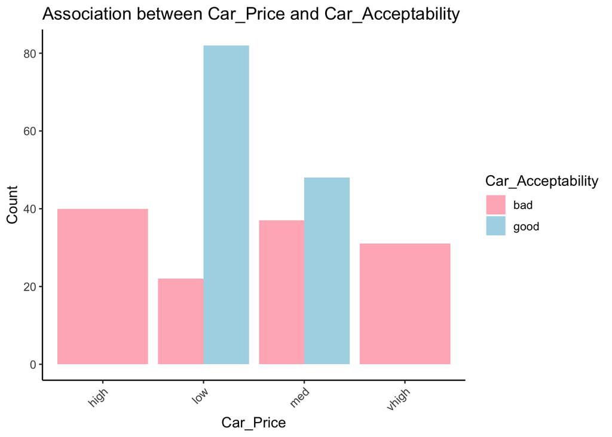

There is a noticeable variation in **car acceptability** across different **car prices**. Higher-priced cars tend to have a **higher frequency** of being rated as `'bad'`, while **lower-priced** cars show a more diverse distribution of acceptability ratings.This suggests that car price could be a **useful** predictor.

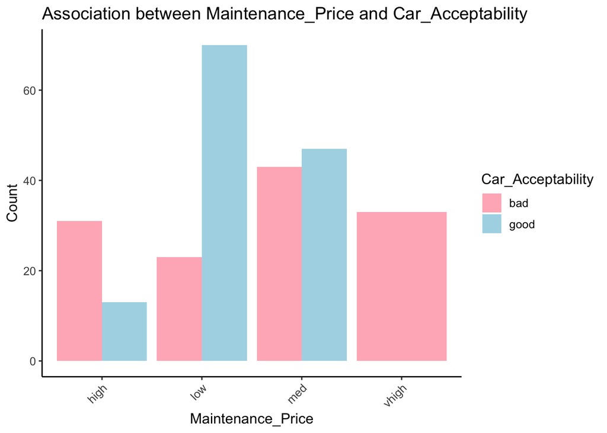

Similar to car price, **maintenance price** shows variation in the **car acceptability** distribution across its levels, with `'low'` showing a distinct pattern (Cars with lower maintenance costs are more likely to have better acceptability ratings). This indicates **potential** predictive power.

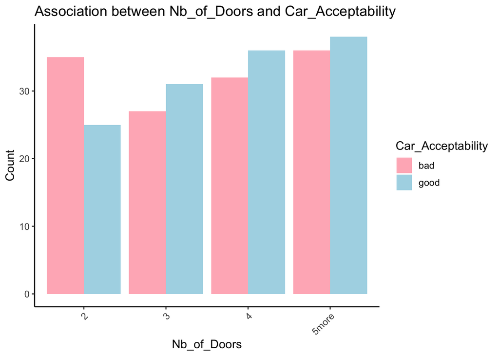

This feature shows a **less clear association** with **car acceptability**. All categories (‘2’, ‘4’, ‘5more’) exhibit a mix of acceptability ratings, although cars with more doors (‘5more’) seem to have a slightly higher frequency of better acceptability. This may suggest that it has **less predictive** power compared to previous predictors.

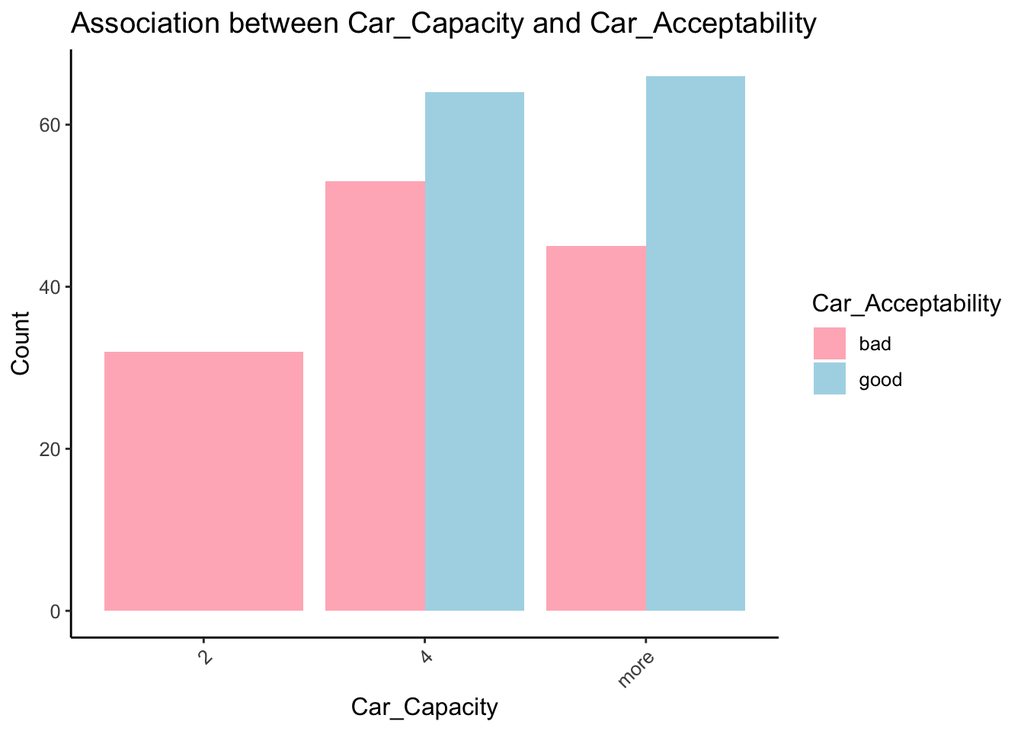

There’s a **noticeable trend** where cars with **higher capacity (‘more’)** are more frequently rated better in terms of **acceptability**, which may indicate **some predictive** utility.

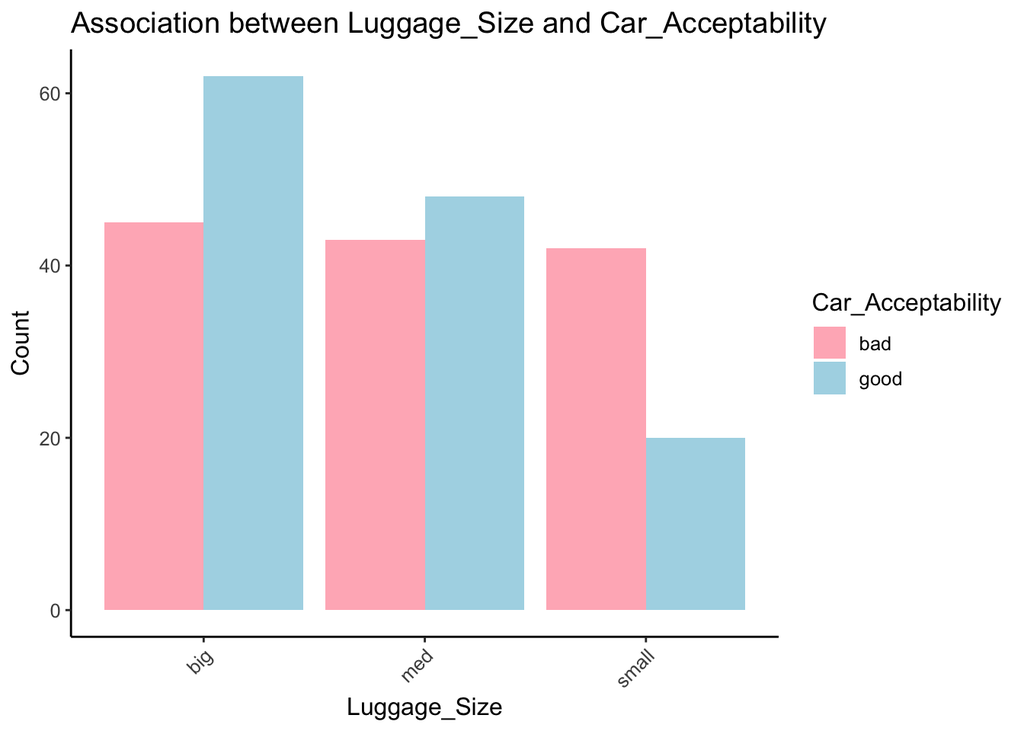

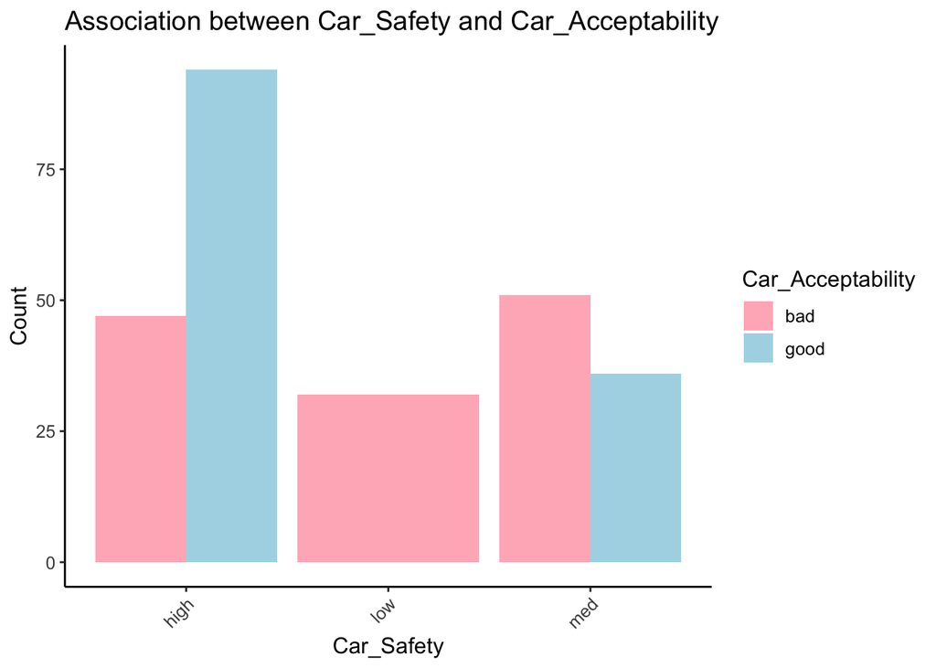

**Car safety** appears to be a **significant factor**. Cars with ‘high’ safety ratings are much more likely to be acceptable compared to those with ‘med’ or ‘low’ safety ratings. This feature appears to be a **strong candidate** for prediction.

## Chi-Squared Test of Independence

After plotting the bar graphs and analyzing the association between **Car acceptability** and each feature, we will be applying the Chi-Squared Test of Independence between each feature and the response to further investigate each association.

Chi-Squared Test Results

| Feature | P_Value |
| --- | --- |
| Car_Price | 4.758916e-23 |
| Maintenance_Price | 7.101377e-14 |
| Nb_of_Doors | 5.256969e-01 |
| Car_Capacity | 9.204434e-09 |
| Luggage_Size | 4.557160e-03 |
| Car_Safety | 1.223847e-11 |

- *Car Price, Maintenance Price, Car Capacity, and Car Safety* show **extremely low p-values**, indicating strong evidence **against the null hypothesis** of independence. This suggests that these features have **significant associations** with car acceptability.
- *Luggage Size* also shows a **significant association (p < 0.05)**, but the strength of this association is less compared to previous features.
- *Number of Doors*, with a **p-value greater than 0.05**, **does not show** a statistically significant association with *car acceptability*. This implies that the *number of doors* might not be a **crucial factor** in determining *car acceptability* in this dataset.
- These findings **align** with the initial graphical analysis and provide a **quantitative** backing to the observed associations.

## Heat Map

After transforming our categorical variables into numerical format, we are able to evaluate the correlations among our variables by utilizing a heatmap.

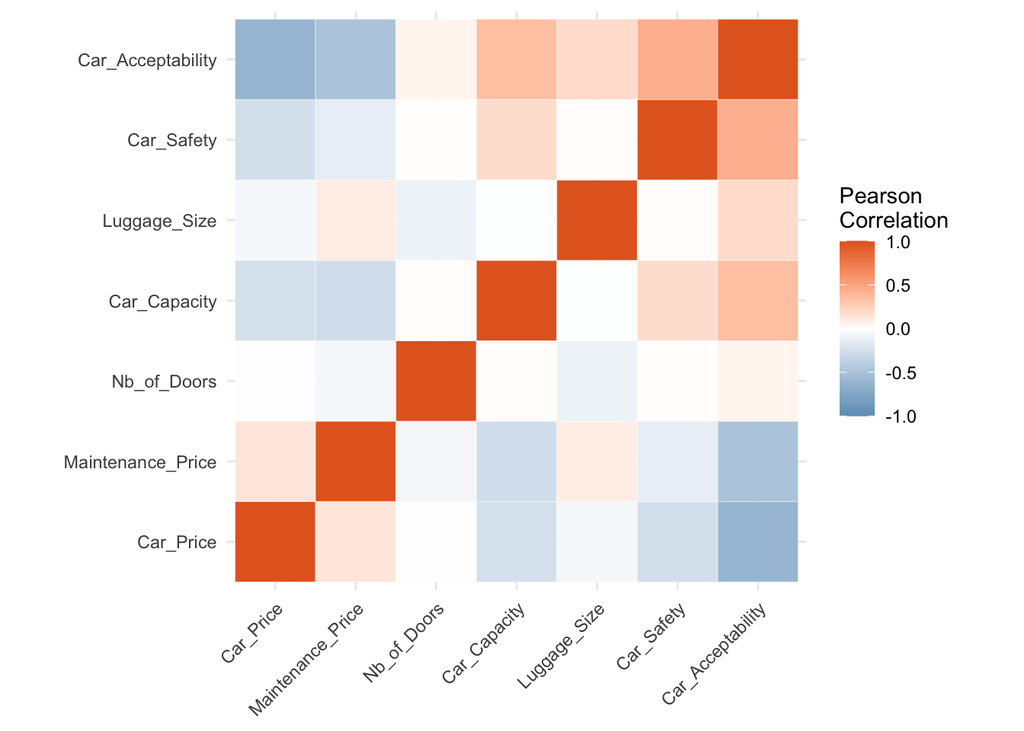

## Violin Plot

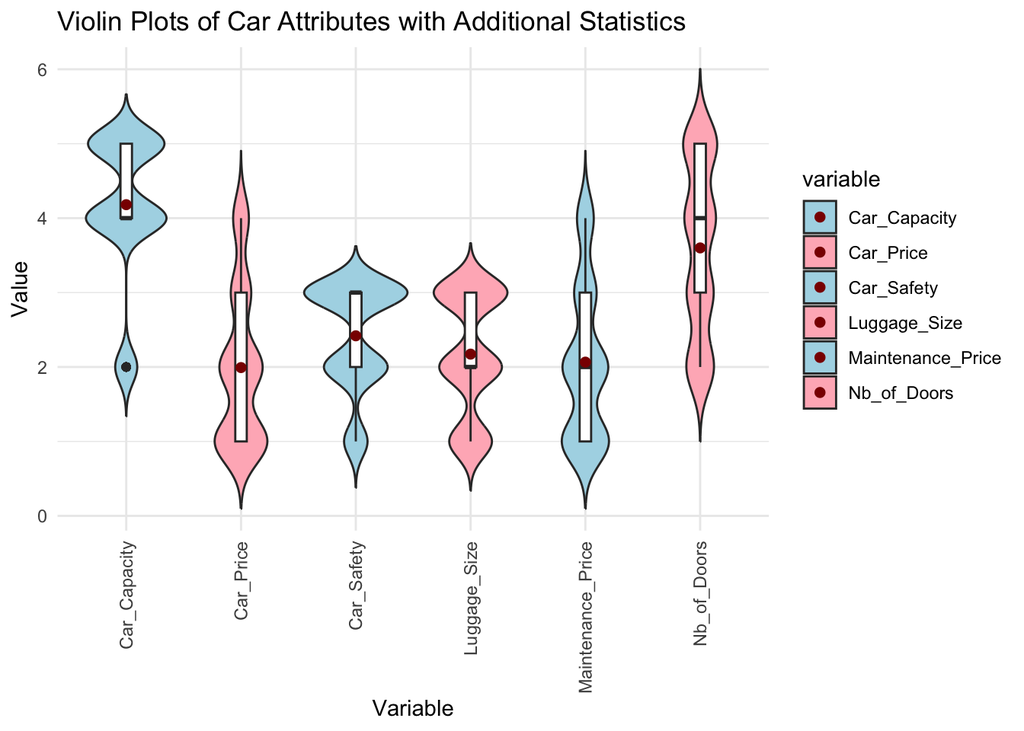

# Validation set approach

- To split the dataset into a training set and a test set using the validation set approach, we will need to first set a random seed for reproducibility and then use a method to split the dataset.
- We decided to split the dataset into *80% Training Set* and *20% Test Set*.
- Opting for an 80-20 split in a dataset of 260 observations offers a balanced approach: it provides 208 observations for robust training, crucial for complex datasets, and reserves 52 for testing to effectively evaluate the model. This split avoids the limitations of a 50-50 split (insufficient training data) and a 70-30 split (excessively large test set), striking a good balance between reducing bias and assessing model variance.
- We will use `createDataPartition function` from the caret package instead of the `sample function` since although `sample()` provides a basic method for random sampling and can be used for data splitting, `createDataPartition()` offers a more specialized and balanced approach, particularly useful for maintaining class proportions in classification problems.

```r
set.seed(11)
partition <- createDataPartition(y = data$Car_Acceptability, p = 0.80, list = FALSE)
training_set <- data[partition, ]
test_set <- data[-partition, ]
```

# Logistic Regression

- First, we will begin by fitting the model with all the dataset features.

```r
set.seed(11)

glm1.fit <- glm(Car_Acceptability ~ Car_Price + Maintenance_Price +
                 Car_Capacity + Luggage_Size + Nb_of_Doors+
                 Car_Safety, data = training_set, family = binomial)
summary(glm1.fit)
```

```
##
## Call:
## glm(formula = Car_Acceptability ~ Car_Price + Maintenance_Price +
##     Car_Capacity + Luggage_Size + Nb_of_Doors + Car_Safety, family = binomial,
##     data = training_set)
##
## Coefficients:
##                   Estimate Std. Error z value Pr(>|z|)
## (Intercept)       -14.6617     8.1004  -1.810 0.070297 .
## Car_Price          -8.4903     2.2138  -3.835 0.000125 ***
## Maintenance_Price  -8.3615     2.4479  -3.416 0.000636 ***
## Car_Capacity        2.5921     1.1193   2.316 0.020568 *
## Luggage_Size        4.7823     1.5839   3.019 0.002533 **
## Nb_of_Doors         0.6346     0.7517   0.844 0.398563
## Car_Safety          8.7170     2.5647   3.399 0.000677 ***
## ---
## Signif. codes:  0 '***' 0.001 '**' 0.01 '*' 0.05 '.' 0.1 ' ' 1
##
## (Dispersion parameter for binomial family taken to be 1)
##
##     Null deviance: 288.349  on 207  degrees of freedom
## Residual deviance:  22.673  on 201  degrees of freedom
## AIC: 36.673
##
## Number of Fisher Scoring iterations: 10
```

- *Car Price, Maintenance Price, and Car Safety* seemed to be **highly significant**.
- *Car Capacity and Luggage Size* seemed to be **significant**.
- *Number of Doors* seemed to be **not significant** where the number of doors doesn’t seem to have a significant effect on car acceptability.
- As a result, we will fit our logistic model **without** the *Nb of Doors* variable, and analyze its performance.

```r
set.seed(11)
glm.fit <- glm(Car_Acceptability ~ Car_Price + Maintenance_Price +
                 Car_Capacity + Luggage_Size +
                 Car_Safety, data = training_set, family = binomial)
summary(glm.fit)
```

```
##
## Call:
## glm(formula = Car_Acceptability ~ Car_Price + Maintenance_Price +
##     Car_Capacity + Luggage_Size + Car_Safety, family = binomial,
##     data = training_set)
##
## Coefficients:
##                   Estimate Std. Error z value Pr(>|z|)
## (Intercept)       -10.7584     6.1147  -1.759 0.078503 .
## Car_Price          -8.2572     2.0548  -4.019 5.86e-05 ***
## Maintenance_Price  -7.8257     2.0711  -3.779 0.000158 ***
## Car_Capacity        2.2846     0.9869   2.315 0.020618 *
## Luggage_Size        4.5169     1.4456   3.125 0.001780 **
## Car_Safety          8.3074     2.3340   3.559 0.000372 ***
## ---
## Signif. codes:  0 '***' 0.001 '**' 0.01 '*' 0.05 '.' 0.1 ' ' 1
##
## (Dispersion parameter for binomial family taken to be 1)
##
##     Null deviance: 288.349  on 207  degrees of freedom
## Residual deviance:  23.488  on 202  degrees of freedom
## AIC: 35.488
##
## Number of Fisher Scoring iterations: 10
```

- In terms of **significance levels**, we obtain the same significance codes for the different variables as in the previous model indicating similar significance levels.
- *Intercept*: The intercept’s coefficient is -10.7584 with a p-value of 0.078503, indicating it is **not statistically** significant at the conventional 0.05 level.
- **Higher** *Car_Price and Maintenance_Price* with **negative coefficients**, negatively affect acceptability, suggesting that more expensive cars or those with higher maintenance costs are less likely to be deemed acceptable.
- *Car_Capacity, Luggage_Size, and Car_Safety* with **positive coefficients**, positively influence acceptability, meaning cars with larger capacity, more luggage space, and better safety features are more likely to be considered acceptable.
- **Logistic Regression Plot** illustrating the above findings:

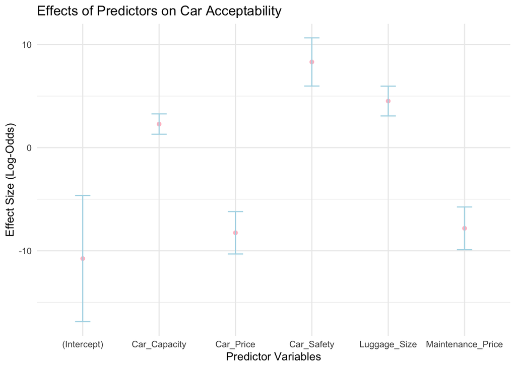

- **Confusion Matrix**:

```r
set.seed(11)

predictions_prob = predict(glm.fit, test_set, type ="response")
predictions <- ifelse(predictions_prob > 0.5, 1, 0)
predictions = as.integer(predictions)

# Print the confusion matrix
confusion_matrix <- table(Actual = test_set$Car_Acceptability, Predicted = predictions)
print(confusion_matrix)
```

```
##       Predicted
## Actual  0  1
##      0 22  4
##      1  1 25
```

- **True Negatives (TN)**: The number of observations correctly predicted as not acceptable `22`.
- **False Positives (FP)**: The number of observations incorrectly predicted as acceptable when they are actually not `4`.
- **False Negatives (FN)**: The number of observations incorrectly predicted as not acceptable when they are actually acceptable `1`.
- **True Positives (TP)**: The number of observations correctly predicted as acceptable `25`.

```
## [1] "Accuracy for Logistic Regression: 0.903846153846154"
```

```
## [1] "Test Error for Logistic Regression: 0.0961538461538461"
```

```
## [1] "Recall for Logistic Regression: 0.846153846153846"
```

```
## [1] "Precision for Logistic Regression: 0.956521739130435"
```

```
## [1] "F1 Score for Logistic Regression: 0.89795918367347"
```

# LDA

- Fitting the LDA Model:

```r
set.seed(11)
lda.fit <- lda(Car_Acceptability ~ Car_Price+Maintenance_Price +
                 Car_Capacity + Luggage_Size + Car_Safety, data = training_set)

lda.fit
```

```
## Call:
## lda(Car_Acceptability ~ Car_Price + Maintenance_Price + Car_Capacity +
##     Luggage_Size + Car_Safety, data = training_set)
##
## Prior probabilities of groups:
##   0   1
## 0.5 0.5
##
## Group means:
##   Car_Price Maintenance_Price Car_Capacity Luggage_Size Car_Safety
## 0  2.596154          2.615385     3.875000     2.019231   2.076923
## 1  1.365385          1.586538     4.528846     2.336538   2.740385
##
## Coefficients of linear discriminants:
##                          LD1
## Car_Price         -0.9386689
## Maintenance_Price -0.8253472
## Car_Capacity       0.2428002
## Luggage_Size       0.5279206
## Car_Safety         0.7692967
```

- The model assumes an equal chance of a car being acceptable or not before considering these factors.
- Group Means: These are the average values of each predictor variable for each class. Notably, the group means for *Car_Price and Maintenance_Price* are **higher for the non-acceptable class** (0) than the acceptable class (1), suggesting that higher prices may be associated with non-acceptability. Conversely, *Car_Capacity, Luggage_Size, and Car_Safety* have **higher means for the acceptable class**, indicating that these features might contribute positively to a car’s acceptability.
- The LDA model output suggests that higher car and maintenance prices with `negative coefficients` contribute to cars being classified as non-acceptable, while greater capacity, luggage size, and safety with `positive coefficients` are associated with acceptability.
- Performance of LDA on Test Data Set:

```r
set.seed(11)
ldaPredictions <- predict(lda.fit, newdata = test_set)
```

```
##          Actual
## Predicted  0  1
##         0 21  0
##         1  5 26
```

```
## [1] "Accuracy for LDA: 0.903846153846154"
```

```
## [1] "Test Error for LDA: 0.0961538461538461"
```

```
## [1] "Recall for LDA: 0.838709677419355"
```

```
## [1] "Precision for LDA: 1"
```

```
## [1] "F1 Score for LDA: 0.912280701754386"
```

# QDA

```r
set.seed(11)
qda.fit <- qda(Car_Acceptability ~ Car_Price+Maintenance_Price +
                 Car_Capacity + Luggage_Size + Car_Safety, data = training_set)
qda.fit
```

```
## Call:
## qda(Car_Acceptability ~ Car_Price + Maintenance_Price + Car_Capacity +
##     Luggage_Size + Car_Safety, data = training_set)
##
## Prior probabilities of groups:
##   0   1
## 0.5 0.5
##
## Group means:
##   Car_Price Maintenance_Price Car_Capacity Luggage_Size Car_Safety
## 0  2.596154          2.615385     3.875000     2.019231   2.076923
## 1  1.365385          1.586538     4.528846     2.336538   2.740385
```

- QDA produces **same results** of `Group Means` and `Prior Probabilities` as LDA.
- Performance of QDA on Test Data Set:

```r
set.seed(11)
qdaPredictions <- predict(qda.fit, newdata = test_set)
```

```
##          Actual
## Predicted  0  1
##         0 23  0
##         1  3 26
```

```
## [1] "Accuracy for QDA: 0.942307692307692"
```

```
## [1] "Test Error for QDA: 0.0576923076923077"
```

```
## [1] "Recall for QDA: 0.896551724137931"
```

```
## [1] "Precision for QDA: 1"
```

```
## [1] "F1 Score for QDA: 0.945454545454545"
```

# ROC Curves

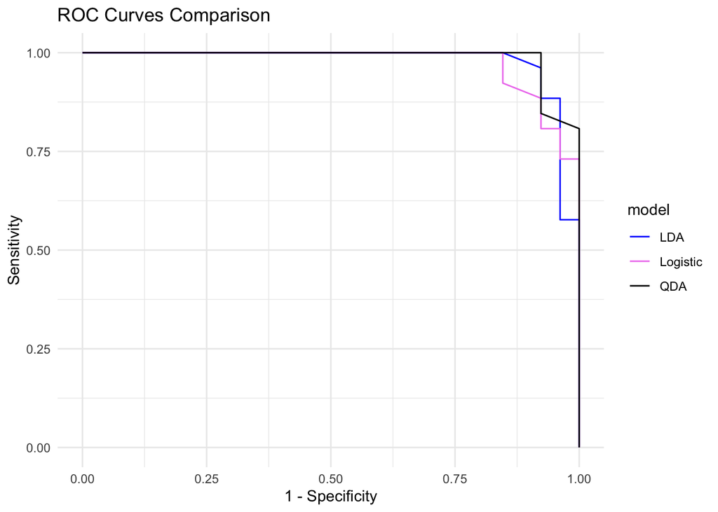

```
## AUC for Logistic Regression: 0.9748521
```

```
## AUC for LDA: 0.9778107
```

```
## AUC for QDA: 0.9866864
```

# KNN

- Fitting the KNN model with **different k values** and testing the accuracy and test error rate for each.

```r
# Function to perform KNN and return accuracy
performKNN <- function(k, featuresTrain, featuresTest, targetTrain, targetTest) {
  knnPrediction <- knn(featuresTrain, featuresTest, targetTrain, k = k)
  confusionMatrix <- table(Predicted = knnPrediction, Actual = targetTest)
  accuracy <- sum(diag(confusionMatrix)) / sum(confusionMatrix)
  return(accuracy)
}

# K values to test
kValues <- c(3, 5, 7, 9, 15, 20,50)
results <- sapply (kValues, performKNN, featureDataTrain, featureDataTest, targetDataTrain, targetDataTest)

# Print accuracy amd test error for each k
sapply(1:length(kValues), function(i) {
  (paste("For k =", kValues[i], ", Accuracy =", results[i], ", Test Error: ", 1 - results[i]))
})
```

```
## [1] "For k = 3 , Accuracy = 0.846153846153846 , Test Error:  0.153846153846154"
## [2] "For k = 5 , Accuracy = 0.807692307692308 , Test Error:  0.192307692307692"
## [3] "For k = 7 , Accuracy = 0.807692307692308 , Test Error:  0.192307692307692"
## [4] "For k = 9 , Accuracy = 0.807692307692308 , Test Error:  0.192307692307692"
## [5] "For k = 15 , Accuracy = 0.807692307692308 , Test Error:  0.192307692307692"
## [6] "For k = 20 , Accuracy = 0.865384615384615 , Test Error:  0.134615384615385"
## [7] "For k = 50 , Accuracy = 0.788461538461538 , Test Error:  0.211538461538462"
```

- KNN has seemed to have the lowest *accuracy of 0.86* and highest *test error of 0.13* among LDA, QDA, and Logistic Regression with `k=20`.

### Plotting K values and Error Rate

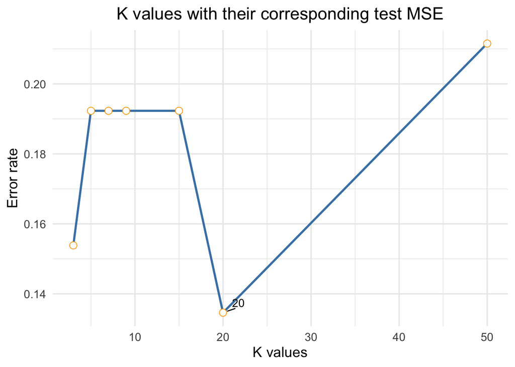

- At **K<20**, the error rate is relatively high, suggesting that the model is **overfitting** to the noise or outliers in the training data.
- There is an **optimal** K value around **K=20** where the error rate is at its lowest, which balances the *bias-variance trade-off* effectively..
- As K **increases** beyond **20**, the error rate begins to rise significantly, suggesting that the model starts to **underfit** the data as it considers more distant neighbors.

# K-Fold Cross Validation

- We will perform **5-Fold Cross Validation** for the *QDA* method.

```r
# Refer to the Rmd File for the implementation of cv_qda
result <- cv_qda(data, Car_Acceptability ~ Car_Price + Maintenance_Price
          + Car_Capacity + Luggage_Size + Car_Safety, K = 5, seed = 11)
print(result)
```

```
## $formula
## Car_Acceptability ~ Car_Price + Maintenance_Price + Car_Capacity +
##     Luggage_Size + Car_Safety
##
## $K
## [1] 5
##
## $average_accuracy
## [1] 0.9807692
##
## $seed
## [1] 11
```

- **Cross-Validation Technique**: The model’s predictive accuracy was assessed using 5-fold cross-validation. This method enhances the reliability of the accuracy estimate by training and validating the model on different subsets of the dataset.
- **Number of Folds (K)**: The value of K was chosen to be 5. This number is a standard practice in cross-validation, balancing the trade-off between training set size and the variance of the model’s accuracy estimate.
- **Average Accuracy**: The average accuracy across the 5 folds was approximately `98.08%`, indicating a strong predictive performance of the model.

### Cross-validation VS validation approach

The enhanced performance with 5-fold cross-validation, as compared to the traditional validation approach **94.23% accuracy**, indicates that cross-validation provides a **more robust** and **generalized assessment**. This is likely because cross-validation reduces the risk of overfitting by testing the model on multiple subsets of the data, thereby offering a more comprehensive evaluation of the model’s true predictive capabilities.

# Bootstrap

- We will perform the bootsrap on the logistic regression model and analyze the results to assess the variability of the estimates.

```r
data$Car_Acceptability <- as.integer(data$Car_Acceptability)

boot.fn=function(data,index){
 return(coef(glm.fit <- glm(Car_Acceptability ~ Car_Price + Maintenance_Price +
                 Car_Capacity + Luggage_Size +
                 Car_Safety, data = data, family = "binomial", subset=index)))
  }

boot.fn(data,1:260)
```

```
##       (Intercept)         Car_Price Maintenance_Price      Car_Capacity
##         -7.878977         -7.392637         -6.520129          1.808901
##      Luggage_Size        Car_Safety
##          3.258332          7.364888
```

- Creating bootstrap estimates by randomly sampling from among the observations with replacement.

```r
boot.fn(data,sample(260,260,replace=TRUE))
```

```
##       (Intercept)         Car_Price Maintenance_Price      Car_Capacity
##          7.775937        -26.675196        -25.587278          1.850812
##      Luggage_Size        Car_Safety
##          4.138152         27.493074
```

- Using `boot()` function to compute the standard errors of `5 bootstrap estimates`.

```r
boot(data ,boot.fn , 5)
```

```
##
## ORDINARY NONPARAMETRIC BOOTSTRAP
##
##
## Call:
## boot(data = data, statistic = boot.fn, R = 5)
##
##
## Bootstrap Statistics :
##      original      bias    std. error
## t1* -7.878977   2.3677516    8.412786
## t2* -7.392637 -11.7731799   12.474516
## t3* -6.520129 -11.3993911   11.763928
## t4*  1.808901   0.4152781    2.167695
## t5*  3.258332   4.5114748    7.592462
## t6*  7.364888  11.1145565   11.459364
```

- A **positive bias** for the intercept and some coefficients suggests overestimation in the bootstrap samples.
- **Negative biases** for *Car_Price and Maintenance_Price coefficients*, combined with the **largest standard errors**, show these estimates are highly variable and possibly underestimated.
- *Car_Capacity* has a relatively **smaller standard error**, indicating a more stable estimate.
- Both *Luggage_Size and Car_Safety coefficients* exhibit **positive biases**, with *Car_Safety* having a notably **high positive bias**, implying potential overestimation.

# Conclusion